# Validation

Validation of algorithms and transformation results.

Chap 7. Validação

- Section 7.3 Resultados
  - Section 7.3.2 Semantic Annotation
    - Classificação de regras operativas, fatos, termos e nomes
  - Section 7.3.3 nlp2sbvr

## Google colab

```python
%load_ext autoreload
%autoreload 2

import sys

IN_COLAB = 'google.colab' in sys.modules

if IN_COLAB:
  from google.colab import drive
  drive.mount('/content/drive')
  !rm -rf cfr2sbvr configuration checkpoint
  !git clone https://github.com/asantos2000/master-degree-santos-anderson.git cfr2sbvr
  %pip install -r cfr2sbvr/code/requirements.txt
  !cp -r cfr2sbvr/code/src/configuration .
  !cp -r cfr2sbvr/code/src/checkpoint .
  !cp -r cfr2sbvr/code/config.colab.yaml config.yaml
  DEFAULT_CONFIG_FILE="config.yaml"
else:
  DEFAULT_CONFIG_FILE="../config.yaml"
```

## Imports

```python
# Standard library imports
from datetime import datetime
import json
import time
from typing import List
import os
import re
from collections import Counter

# Third-party imports
import matplotlib.pyplot as plt
import numpy as np
import pandas as pd
import seaborn as sns
import statsmodels.api as sm
from openai import OpenAI
from scipy.spatial.distance import cosine
import xlsxwriter
import openpyxl
from pydantic import BaseModel, Field


# Local application/library-specific imports
import checkpoint.main as checkpoint
from checkpoint.main import (
    save_checkpoint,
    restore_checkpoint,
    get_all_checkpoints,
    get_elements_from_checkpoints,
    Document,
)
import configuration.main as configuration
import logging_setup.main as logging_setup
import llm_query.main as llm_query
from llm_query.main import query_instruct_llm
import rules_taxonomy_provider.main as rules_taxonomy_provider
from rules_taxonomy_provider.main import RulesTemplateProvider

DEV_MODE = True

if DEV_MODE:
    # Development mode
    import importlib

    importlib.reload(configuration)
    importlib.reload(logging_setup)
    importlib.reload(checkpoint)
    importlib.reload(llm_query)
    importlib.reload(rules_taxonomy_provider)

# Ensure plots are displayed inline if using a Jupyter notebook
%matplotlib inline

from IPython.display import display
```

## Settings

### Configuration

```python
# Load configuration
config = configuration.load_config(DEFAULT_CONFIG_FILE)
```

### Logging

```python
logger = logging_setup.setting_logging(config["DEFAULT_LOG_DIR"], config["LOG_LEVEL"])
```

```
2024-12-09 23:23:15 - INFO - Logging is set up with daily rotation.
```

## Checkpoints

### Restore the checkpoint

```python
# Restore the checkpoint

# To run after extraction
last_checkpoint = configuration.get_last_filename(
    config["DEFAULT_CHECKPOINT_DIR"], "documents", "json"
)

logger.info(f"{last_checkpoint=}")

config["DEFAULT_CHECKPOINT_FILE"] = last_checkpoint

manager = restore_checkpoint(filename=config["DEFAULT_CHECKPOINT_FILE"])
```

```
2024-12-09 23:23:16 - INFO - last_checkpoint='../data/checkpoints/documents-2024-12-08-10.json'
2024-12-09 23:23:16 - INFO - DocumentManager restored from file: ../data/checkpoints/documents-2024-12-08-10.json
2024-12-09 23:23:16 - INFO - Checkpoint restored from ../data/checkpoints/documents-2024-12-08-10.json.
```

## General functions

```python
def remove_section_symbol(input_string: str) -> str:
    """
    Removes the '§' symbol from the input string and trims whitespace.

    Args:
        input_string (str): The string from which to remove the '§' symbol.

    Returns:
        str: The cleaned string without the '§' symbol and leading/trailing whitespace.

    Raises:
        TypeError: If 'input_string' is not a string.
    """
    if not isinstance(input_string, str):
        raise TypeError("input_string must be a string")
    return input_string.replace("§", "").strip()
```

```python
def prompt_analysis(raw_data, output_dir):
    # Create a DataFrame from the raw data
    data = pd.DataFrame(
        raw_data,
        columns=["filename", "doc_type", "elapsed_time", "usage", "created", "model"],
    )

    # Transform 'created' to a human-readable datetime format
    data["created"] = pd.to_datetime(data["created"], unit="s")

    # Extract relevant information from the 'usage' dictionary
    data["completion_tokens"] = data["usage"].apply(lambda x: x["completion_tokens"])
    data["prompt_tokens"] = data["usage"].apply(lambda x: x["prompt_tokens"])
    data["total_tokens"] = data["usage"].apply(lambda x: x["total_tokens"])

    # Define a function to get reference model context length
    def get_reference_model_context_length(model):
        return reference_models.get(
            model, 128_000
        )  # Default to 128,000 if model is unknown

    # Define a function to get the price per million tokens
    def get_price_per_million_tokens(model):
        return price_per_million_tokens.get(
            model, 2.50
        )  # Default to 2.50 if model is unknown

    # Add context length and price per million tokens columns
    data["reference_context_length"] = data["model"].apply(
        get_reference_model_context_length
    )
    data["price_per_million_tokens"] = data["model"].apply(get_price_per_million_tokens)

    # Overall Statistics
    total_tokens = data["total_tokens"].sum()
    num_samples = len(data)
    average_elapsed_time = data["elapsed_time"].mean()
    estimated_cost = (
        data["total_tokens"] / 1_000_000 * data["price_per_million_tokens"]
    ).sum()
    average_percentage_context_length = (
        data["total_tokens"] / data["reference_context_length"]
    ).mean() * 100
    min_created = data["created"].min().strftime("%Y-%m-%d %H:%M:%S")
    max_created = data["created"].max().strftime("%Y-%m-%d %H:%M:%S")

    # Add filename column to each statistic for origin tracking
    filename = file_info["filename"]
    # Data and time of the execution
    now = datetime.now().strftime("%Y-%m-%d %H:%M:%S")

    # Create Overall Statistics DataFrame
    overall_stats_df = pd.DataFrame(
        [
            {
                "Total Tokens": total_tokens,
                "Number of Samples": num_samples,
                "Average Elapsed Time (s)": average_elapsed_time,
                "Estimated Cost (USD)": estimated_cost,
                "Average Percentage of Context Length (%)": average_percentage_context_length,
                "Min Created Timestamp": min_created,
                "Max Created Timestamp": max_created,
                "origin": filename,
                "run_at": now,
            }
        ]
    )

    # Statistics by Sample Type (doc_type)
    stats_by_doc_type = (
        data.groupby("doc_type")
        .agg(
            total_tokens=("total_tokens", "sum"),
            num_samples=("doc_type", "count"),
            average_elapsed_time=("elapsed_time", "mean"),
            average_tokens=("total_tokens", "mean"),
            estimated_cost=(
                "total_tokens",
                lambda x: (x.sum() / 1_000_000)
                * data.loc[x.index, "price_per_million_tokens"].mean(),
            ),
            average_percentage_context_length=(
                "total_tokens",
                lambda x: (
                    x.mean() / data.loc[x.index, "reference_context_length"].mean()
                )
                * 100,
            ),
        )
        .reset_index()
    )
    stats_by_doc_type["filename"] = filename
    stats_by_doc_type["run_at"] = now

    # Statistics by Model
    stats_by_model = (
        data.groupby("model")
        .agg(
            total_tokens=("total_tokens", "sum"),
            num_samples=("model", "count"),
            average_elapsed_time=("elapsed_time", "mean"),
            average_tokens=("total_tokens", "mean"),
            average_percentage_context_length=(
                "total_tokens",
                lambda x: (x.mean() / get_reference_model_context_length(x.name)) * 100,
            ),
        )
        .reset_index()
    )
    stats_by_model["filename"] = filename
    stats_by_model["run_at"] = now

    # Add estimated cost and cost columns separately since they require different calculations
    def calculate_group_cost(model):
        price = get_price_per_million_tokens(model)
        total_tokens = data[data["model"] == model]["total_tokens"].sum()
        return (total_tokens / 1_000_000) * price

    stats_by_model["estimated_cost"] = stats_by_model["model"].apply(
        calculate_group_cost
    )
    stats_by_model["cost"] = stats_by_model["estimated_cost"]

    # Calculate Tokens per Second
    # Ensure there are no division by zero issues by filtering out zero elapsed times
    data = data[data["elapsed_time"] > 0]
    data["tokens_per_second"] = data["total_tokens"] / data["elapsed_time"]

    # Write the statistics to an Excel file
    file_name = os.path.join(output_dir, "prompt-analysis.xlsx")

    with pd.ExcelWriter(file_name, engine="openpyxl") as writer:
        # Replace the data on each sheet with the new data
        overall_stats_df.to_excel(writer, sheet_name="Overall Statistics", index=False)
        stats_by_doc_type.to_excel(
            writer, sheet_name="Statistics by Sample Type", index=False
        )
        stats_by_model.to_excel(writer, sheet_name="Statistics by Model", index=False)
        additional_stats_df = pd.DataFrame(
            [
                {
                    "Average Completion Tokens": data["completion_tokens"].mean(),
                    "Average Prompt Tokens": data["prompt_tokens"].mean(),
                    "Average Total Tokens per Sample": data["total_tokens"].mean(),
                    "Total Elapsed Time (s)": data["elapsed_time"].sum(),
                    "Average Tokens per Second": data["tokens_per_second"].mean(),
                    "origin": filename,
                    "run_at": now,
                }
            ]
        )
        additional_stats_df.to_excel(
            writer, sheet_name="Additional Statistics", index=False
        )
        data.to_excel(writer, sheet_name="Raw Data", index=False)

        # Explanation Page
        explanation_data = {
            "Sheet Name": [
                "Overall Statistics",
                "Statistics by Sample Type",
                "Statistics by Model",
                "Additional Statistics",
                "Raw Data",
            ],
            "Description": [
                "Summary statistics of the entire dataset, including total tokens, number of samples, average elapsed time, and estimated cost.",
                "Statistics broken down by sample type (doc_type), including the total number of tokens and cost estimates for each type.",
                "Statistics grouped by the model used, showing token utilization, cost, and elapsed time for each model.",
                "Additional aggregated metrics such as average completion tokens, prompt tokens, total tokens per sample, and processing time.",
                "The raw data used for generating all the statistics, including individual completions and their details.",
            ],
            "Columns Explained": [
                "Total Tokens: Total number of tokens processed. Number of Samples: Total number of samples. Average Elapsed Time (s): Average time taken for processing. Estimated Cost (USD): Estimated cost for token usage. Average Percentage of Context Length (%): Average percentage of used context length. Min and Max Created Timestamp: The time range of the data collected. Origin: Source filename.",
                "doc_type: Type of document. total_tokens: Sum of tokens per document type. num_samples: Number of samples of this type. average_elapsed_time: Average time taken per document type. average_tokens: Average tokens per sample. estimated_cost: Estimated cost for tokens of this type. average_percentage_context_length: Average percentage of context length used. filename: Source filename.",
                "model: Model name. total_tokens: Total number of tokens used by the model. num_samples: Number of samples processed by the model. average_elapsed_time: Average processing time for the model. average_tokens: Average number of tokens per sample. average_percentage_context_length: Average context length percentage used. filename: Source filename. estimated_cost/cost: Cost for the tokens used by the model.",
                "Average Completion Tokens: Average number of completion tokens per sample. Average Prompt Tokens: Average number of prompt tokens per sample. Average Total Tokens per Sample: Average number of total tokens per sample. Total Elapsed Time (s): Total processing time for all samples. Average Tokens per Second: Average number of tokens processed per second. origin: Source filename.",
                "filename: Source filename. doc_type: Type of document. elapsed_time: Time taken for each document. usage: Token usage details (completion and prompt). created: Timestamp of creation. model: Model used.",
            ],
        }
        explanation_df = pd.DataFrame(explanation_data)
        explanation_df.to_excel(writer, sheet_name="Explanation", index=False)

    # Display Overall Statistics
    overall_stats_df_display = pd.DataFrame(
        [
            {
                "Total Tokens": total_tokens,
                "Number of Samples": num_samples,
                "Average Elapsed Time (s)": average_elapsed_time,
                "Estimated Cost (USD)": estimated_cost,
                "Average Percentage of Context Length (%)": average_percentage_context_length,
                "Min Created Timestamp": min_created,
                "Max Created Timestamp": max_created,
                "origin": filename,
                "run_at": now,
            }
        ]
    )
    print("\nOverall Statistics:")
    print(overall_stats_df_display.to_string(index=False))

    # Display Statistics by Sample Type
    print("\nStatistics by Sample Type (doc_type):")
    print(stats_by_doc_type.to_string(index=False))

    # Display Statistics by Model
    print("\nStatistics by Model:")
    print(stats_by_model.to_string(index=False))

    # Additional Statistics
    additional_stats_df_display = pd.DataFrame(
        [
            {
                "Average Completion Tokens": data["completion_tokens"].mean(),
                "Average Prompt Tokens": data["prompt_tokens"].mean(),
                "Average Total Tokens per Sample": data["total_tokens"].mean(),
                "Total Elapsed Time (s)": data["elapsed_time"].sum(),
                "Average Tokens per Second": data["tokens_per_second"].mean(),
                "origin": filename,
                "run_at": now,
            }
        ]
    )
    print("\nAdditional Statistics:")
    print(additional_stats_df_display.to_string(index=False))
```

```python
# Add similarity_classification based on similarity_score
def classify_similarity(score):
    if score == 1.0:
        return "identical"
    elif score >= 0.9:
        return "close-match"
    else:
        return "not-sure"


# Modify the highlight_similarity function to use three colors
def highlight_similarity(val):
    if val == "identical":
        color = "green"
    elif val == "close-match":
        color = "yellow"
    else:
        color = "red"
    return f"background-color: {color}"
```

```python
def create_df_elements_results(similarity_elements_results):
    # Build the dataframe
    df_results = pd.DataFrame(similarity_elements_results)

    df_results["similarity_classification"] = df_results["similarity_score"].apply(
        classify_similarity
    )

    df_results["classification_match"] = (
        df_results["classification_pred"] == df_results["classification_true"]
    )
    df_results["classification_match_label"] = df_results["classification_match"].map(
        {True: "match", False: "mismatch"}
    )

    df_results["source_match"] = df_results["source_pred"] == df_results["source_true"]
    df_results["source_match_label"] = df_results["source_match"].map(
        {True: "match", False: "mismatch"}
    )

    df_results["id_match"] = df_results["id_pred"] == df_results["id_true"]
    df_results["id_match_label"] = df_results["id_match"].map(
        {True: "match", False: "mismatch"}
    )

    return df_results
```

```python
class JudgeStatement(BaseModel):
    doc_id: str = Field(..., description="Document ID associated with the statement.")
    statement_id: str = Field(
        ...,
        description="A provided string that identifies the statement. e.g., '1', 'Person'.",
    )
    statement: str = Field(..., description="The statement to be transformed.")
    sources: List[str] = Field(..., description="Sources of the statement.")
    semscore: float = Field(..., description="just a copy from input semscore.")
    similarity_score: float = Field(
        ...,
        description="Similarity score between the original and transformed sentences.",
    )
    similarity_score_confidence: float = Field(
        ..., description="Confidence score for the similarity score."
    )
    transformation_accuracy: float = Field(
        ..., description="Accuracy score for the transformation."
    )
    grammar_syntax_accuracy: float = Field(
        ..., description="Accuracy score for the grammar and syntax."
    )
    findings: List[str] = Field(..., description="List of findings.")


class JudgeStatements(BaseModel):
    JudgeStatements: List[JudgeStatement] = Field(
        ..., description="List of judge statements."
    )
```

```python
def get_prompts_for_judge(rules, data_dir):
    rule_template_provider = RulesTemplateProvider(data_dir)

    system_prompts = []
    user_prompts = []

    for rule in rules:
        element_name = rule.get("element_name")

        if element_name == ["Term", "Name"]:
            statement_key = "definition"
            statement_id_key = "signifier"
        else:
            statement_key = "statement"
            statement_id_key = "statement_id"

        user_prompt = get_user_prompt_judge_sentence_similarity(element_name, rule)
        user_prompts.append(user_prompt)
        rule_templates_subtemplates = rule_template_provider.get_rules_template(
            rule["templates_ids"]
        )
        system_prompt = get_system_prompt_judge_sentence_similarity(
            rule_templates_subtemplates
        )
        system_prompts.append(system_prompt)
        logger.debug(system_prompt)
        logger.debug(user_prompt)

    logger.info(f"System prompts for {element_name}s: {len(system_prompts)}")
    logger.info(f"User prompts for {element_name}s: {len(user_prompts)}")

    return system_prompts, user_prompts, element_name
```

```python
def evaluate_statement(element_name, user_prompts, system_prompts, manager):
    # Initialize an empty list to accumulate all responses
    all_responses = []
    elapse_times = []
    completions = []

    # Loop through each pair of user and system prompts with a counter
    for index, (user_prompt, system_prompt) in enumerate(
        zip(user_prompts, system_prompts), start=1
    ):
        logger.info(f"Processing evaluation prompt {index} for {element_name}.")
        logger.debug(system_prompt)
        logger.debug(user_prompt)

        # Query the language model
        response, completion, elapse_time = query_instruct_llm(
            system_prompt=system_prompt,
            user_prompt=user_prompt,
            document_model=JudgeStatements,
            llm_model=config["LLM"]["MODEL"],
            temperature=config["LLM"]["TEMPERATURE"],
            max_tokens=config["LLM"]["MAX_TOKENS"],
        )

        logger.debug(f"{response}")

        # Accumulate the responses in the list
        all_responses.extend(response.JudgeStatements)
        elapse_times.append(elapse_time)
        completions.append(completion.dict())

        logger.info(f"Finished processing evaluation {index}.")

        logger.info("Waiting 2s before processing the next prompt to avoid rate limits")
        time.sleep(2)

    # After the loop, create a single Document with all the accumulated responses
    doc = Document(
        id=f"validation_judge_{element_name.replace(' ', '_')}s",
        type="llm_validation",
        content=all_responses,
        elapsed_times=elapse_times,
        completions=completions,
    )
    manager.add_document(doc)

    logger.info(f"{element_name}s: {len(all_responses)}")

    return all_responses
```

```python
def get_embedding(text, model="text-embedding-3-large"):
    client = OpenAI()
    text = text.replace("\n", " ")
    return client.embeddings.create(input=[text], model=model).data[0].embedding


def cosine_similarity(embedding1, embedding2):
    # Calcula a similaridade de cosseno entre dois embeddings
    embedding1 = np.array(embedding1)
    embedding2 = np.array(embedding2)
    cos_sim = np.dot(embedding1, embedding2) / (
        np.linalg.norm(embedding1) * np.linalg.norm(embedding2)
    )
    return cos_sim


def compare_sentences(sentence1, sentence2):
    # Obtem embeddings para as duas frases
    embedding1 = get_embedding(sentence1)
    embedding2 = get_embedding(sentence2)
    # Calcula a similaridade de cosseno entre os embeddings
    # similarity = cosine_similarity(embedding1, embedding2)
    similarity = 1 - cosine(embedding1, embedding2)
    return similarity
```

```python
# Function to calculate Intraclass Correlation Coefficient (ICC) using statsmodels
def calculate_icc(data):
    """
    Calculate the Intraclass Correlation Coefficient (ICC) using statsmodels.
    data: pandas DataFrame with 'semscore' and 'similarity_score' columns.
    """
    data = data[["semscore", "similarity_score"]].dropna().reset_index(drop=True)
    data["subject"] = data.index
    ratings = data.melt(id_vars=["subject"], var_name="rater", value_name="score")
    model = sm.MixedLM.from_formula(
        "score ~ 1", groups="subject", re_formula="1", data=ratings
    )
    result = model.fit()
    var_components = result.cov_re.iloc[0, 0]
    residual = result.scale
    icc_value = var_components / (var_components + residual)
    return icc_value


# Function to calculate descriptive statistics
def calculate_descriptive_stats(series):
    stats = series.describe()
    stats["range"] = stats["max"] - stats["min"]
    stats["IQR"] = stats["75%"] - stats["25%"]
    return stats


# Function to plot Bland-Altman plot
def plot_bland_altman(df, score1, score2, title, output_dir, filename):
    mean_scores = (df[score1] + df[score2]) / 2
    diff_scores = df[score1] - df[score2]
    diff_mean = diff_scores.mean()
    diff_std = diff_scores.std()
    loa_upper = diff_mean + 1.96 * diff_std
    loa_lower = diff_mean - 1.96 * diff_std

    plt.figure(figsize=(8, 6))
    plt.scatter(mean_scores, diff_scores, alpha=0.7)
    plt.axhline(diff_mean, color="red", linestyle="--")
    plt.axhline(loa_upper, color="grey", linestyle="--")
    plt.axhline(loa_lower, color="grey", linestyle="--")
    plt.xlabel("Mean of Scores")
    plt.ylabel("Difference of Scores")
    plt.title(title)
    plt.grid(True)
    plt.show()

    # Save plot
    plot_path = os.path.join(output_dir, filename)
    plt.savefig(plot_path)
    plt.close()
    return plot_path


# Function to plot scatter plot
def plot_scatter(df, x_col, y_col, title, xlabel, ylabel, output_dir, filename):
    plt.figure(figsize=(8, 6))
    plt.scatter(df[x_col], df[y_col], alpha=0.7)
    plt.xlabel(xlabel)
    plt.ylabel(ylabel)
    plt.title(title)
    plt.grid(True)
    plt.show()

    # Save plot
    plot_path = os.path.join(output_dir, filename)
    plt.savefig(plot_path)
    plt.close()
    return plot_path


# Function to plot histogram
def plot_histogram(series, title, xlabel, output_dir, filename):
    plt.figure(figsize=(8, 6))
    series.hist(bins=20)
    plt.title(title)
    plt.xlabel(xlabel)
    plt.ylabel("Frequency")
    plt.grid(True)
    plt.show()

    # Save plot
    plot_path = os.path.join(output_dir, filename)
    plt.savefig(plot_path)
    plt.close()
    return plot_path


# Function to plot box plot
def plot_boxplot(series, title, ylabel, output_dir, filename):
    plt.figure(figsize=(8, 6))
    series.plot.box()
    plt.title(title)
    plt.ylabel(ylabel)
    plt.grid(True)
    plt.show()

    # Save plot
    plot_path = os.path.join(output_dir, filename)
    plt.savefig(plot_path)
    plt.close()
    return plot_path


# Function to plot density plot
def plot_density(series, title, xlabel, output_dir, filename):
    plt.figure(figsize=(8, 6))
    series.plot(kind="kde")
    plt.title(title)
    plt.xlabel(xlabel)
    plt.grid(True)
    plt.show()

    # Save plot
    plot_path = os.path.join(output_dir, filename)
    plt.savefig(plot_path)
    plt.close()
    return plot_path


# Function to count scores above a threshold
def count_scores_above_threshold(series, threshold):
    count = (series > threshold).sum()
    return count


# Function to plot heatmap
def plot_heatmap(df, title, output_dir, filename):
    plt.figure(figsize=(10, 8))
    sns.heatmap(df.corr(), annot=True, cmap="coolwarm")
    plt.title(title)
    plt.show()

    # Save plot
    plot_path = os.path.join(output_dir, filename)
    plt.savefig(plot_path, bbox_inches="tight")
    plt.close()
    return plot_path


import scipy.stats as stats
import matplotlib.pyplot as plt
import os

# Function to plot Q-Q plot
def plot_qqplot(series, title, output_dir, filename):
    plt.figure(figsize=(8, 6))

    # Gerar o Q-Q plot
    stats.probplot(series, dist="norm", plot=plt)
    plt.title(title)
    plt.grid(True)

    # Exibir o gráfico
    plt.show()

    # Salvar o gráfico
    plot_path = os.path.join(output_dir, filename)
    plt.savefig(plot_path)
    plt.close()
    return plot_path


# Main function to process all elements
def process_all_elements(element_data, output_dir):
    logger.info(f"Processing All Elements\n{'-'*40}")

    # Ensure the output directory exists
    os.makedirs(output_dir, exist_ok=True)

    # Define the path for the Excel file
    excel_file_path = os.path.join(output_dir, "combined_analysis_results.xlsx")

    # Create an Excel writer using XlsxWriter as the engine
    writer = pd.ExcelWriter(excel_file_path, engine="xlsxwriter")
    workbook = writer.book

    # List to store DataFrames for combining data later
    combined_df_list = []

    # List to keep track of image filenames for cleanup
    image_files = []

    # Loop through each element type in element_data
    for element_name, content in element_data.items():
        element_type = element_name  # e.g., 'Operative_Rules'
        logger.info(f"\nProcessing Element Type: {element_type}")

        df = pd.DataFrame(content)

        # Ensure numeric columns are of float type
        numeric_cols = [
            "semscore",
            "similarity_score",
            "similarity_score_confidence",
            "transformation_accuracy",
            "grammar_syntax_accuracy",
        ]
        df[numeric_cols] = df[numeric_cols].astype(float)

        # Add a column for element type
        df["element_type"] = element_type

        # Append to combined data list
        combined_df_list.append(df)

        # Perform analysis on this element type
        sheet_name = element_type[:31]  # Sheet names have a max length of 31 characters
        worksheet = workbook.add_worksheet(sheet_name)
        writer.sheets[sheet_name] = worksheet
```

```python
        # Reset row counter for each sheet
        row = 0

        # Descriptive Statistics
        semscore_stats = calculate_descriptive_stats(df["semscore"])
        similarity_score_stats = calculate_descriptive_stats(df["similarity_score"])

        # Correlations
        pearson_corr = df["semscore"].corr(df["similarity_score"])
        spearman_corr = df["semscore"].corr(df["similarity_score"], method="spearman")

        # Display statistics in the notebook
        print("Semscore Statistics:")
        display(semscore_stats.to_frame())
        print("\nSimilarity Score Statistics:")
        display(similarity_score_stats.to_frame())
        print(
            f"\nPearson Correlation between semscore and similarity_score: {pearson_corr:.4f}"
        )
        print(
            f"Spearman Correlation between semscore and similarity_score: {spearman_corr:.4f}"
        )

        # Write Semscore Statistics to Excel
        semscore_stats_df = semscore_stats.to_frame(name="Semscore Statistics")
        semscore_stats_df.to_excel(
            writer, sheet_name=sheet_name, startrow=row, startcol=0
        )
        row += len(semscore_stats_df) + 3  # Increment row for next section

        # Write Similarity Score Statistics to Excel
        similarity_score_stats_df = similarity_score_stats.to_frame(
            name="Similarity Score Statistics"
        )
        similarity_score_stats_df.to_excel(
            writer, sheet_name=sheet_name, startrow=row, startcol=0
        )
        row += len(similarity_score_stats_df) + 3

        # Write Correlations to Excel
        worksheet.write(
            row, 0, "Pearson Correlation between semscore and similarity_score"
        )
        worksheet.write(row, 1, pearson_corr)
        row += 1
        worksheet.write(
            row, 0, "Spearman Correlation between semscore and similarity_score"
        )
        worksheet.write(row, 1, spearman_corr)
        row += 3

        # Intraclass Correlation Coefficient (ICC)
        icc_value = calculate_icc(df[["semscore", "similarity_score"]])
        print(
            f"\nIntraclass Correlation Coefficient (ICC) between semscore and similarity_score: {icc_value:.4f}"
        )
        worksheet.write(row, 0, "Intraclass Correlation Coefficient (ICC)")
        worksheet.write(row, 1, icc_value)
        row += 3

        # Q-Q Plot for similarity_score
        plot_filename = f"qqplot_similarity_score_{element_type}.png"
        plot_path = plot_qqplot(
            df["similarity_score"],
            f"Q-Q Plot of similarity_score - {element_type}",
            output_dir,
            plot_filename,
        )

        # Bland-Altman Plot
        plot_filename = f"bland_altman_{element_type}.png"
        plot_path = plot_bland_altman(
            df,
            "semscore",
            "similarity_score",
            f"Bland-Altman Plot - {element_type}",
            output_dir,
            plot_filename,
        )
        worksheet.insert_image(row, 0, plot_path)
        row += 20
        image_files.append(plot_path)

        # Scatter Plot
        plot_filename = f"scatter_semscore_similarity_{element_type}.png"
        plot_path = plot_scatter(
            df,
            "semscore",
            "similarity_score",
            f"Semscore vs Similarity Score - {element_type}",
            "Semscore",
            "Similarity Score",
            output_dir,
            plot_filename,
        )
        worksheet.insert_image(row, 0, plot_path)
        row += 20
        image_files.append(plot_path)

        # Histograms for semscore
        plot_filename = f"histogram_semscore_{element_type}.png"
        plot_path = plot_histogram(
            df["semscore"],
            f"Histogram of Semscore - {element_type}",
            "Semscore",
            output_dir,
            plot_filename,
        )
        worksheet.insert_image(row, 0, plot_path)
        row += 20
        image_files.append(plot_path)

        # Box Plot for semscore
        plot_filename = f"boxplot_semscore_{element_type}.png"
        plot_path = plot_boxplot(
            df["semscore"],
            f"Box Plot of Semscore - {element_type}",
            "Semscore",
            output_dir,
            plot_filename,
        )
        worksheet.insert_image(row, 0, plot_path)
        row += 20
        image_files.append(plot_path)

        # Box Plot for similarity_score
        plot_filename = f"boxplot_similarity_score_{element_type}.png"
        plot_path = plot_boxplot(
            df["similarity_score"],
            f"Box Plot of similarity_score - {element_type}",
            "similarity_score",
            output_dir,
            plot_filename,
        )
        worksheet.insert_image(row, 0, plot_path)
        row += 20
        image_files.append(plot_path)

        # Density Plot for semscore
        plot_filename = f"density_semscore_{element_type}.png"
        plot_path = plot_density(
            df["semscore"],
            f"Density Plot of Semscore - {element_type}",
            "Semscore",
            output_dir,
            plot_filename,
        )
        worksheet.insert_image(row, 0, plot_path)
        row += 20
        image_files.append(plot_path)

        # Density Plot for similarity_score
        plot_filename = f"density_similarity_score_{element_type}.png"
        plot_path = plot_density(
            df["similarity_score"],
            f"Density Plot of similarity_score - {element_type}",
            "similarity_score",
            output_dir,
            plot_filename,
        )
        worksheet.insert_image(row, 0, plot_path)
        row += 20
        image_files.append(plot_path)

        # Counts of Scores Above Threshold
        threshold = 0.8
        count_above_threshold = count_scores_above_threshold(
            df["transformation_accuracy"], threshold
        )
        print(
            f"\nCount of Transformation Accuracy scores above {threshold}: {count_above_threshold}"
        )
        worksheet.write(row, 0, f"Count of Transformation Accuracy > {threshold}")
        worksheet.write(row, 1, count_above_threshold)
        row += 3
```

```python
        # Heatmap of Correlation Matrix
        plot_filename = f"heatmap_{element_type}.png"
        plot_path = plot_heatmap(
            df[numeric_cols],
            f"Correlation Matrix Heatmap - {element_type}",
            output_dir,
            plot_filename,
        )
        worksheet.insert_image(row, 0, plot_path)
        row += 25
        image_files.append(plot_path)

        # Save the DataFrame with the original data to a separate sheet
        data_sheet_name = f"{sheet_name}_Data"[:31]
        df.to_excel(writer, sheet_name=data_sheet_name, index=False)

    # Combine all DataFrames
    combined_df = pd.concat(combined_df_list, ignore_index=True)

    # Perform combined analysis
    print("\nProcessing Combined Data")
    sheet_name = "Combined_Analysis"
    worksheet = workbook.add_worksheet(sheet_name)
    writer.sheets[sheet_name] = worksheet
    row = 0

    # Ensure numeric columns are of float type
    combined_df[numeric_cols] = combined_df[numeric_cols].astype(float)

    # Descriptive Statistics for combined semscore
    semscore_stats = calculate_descriptive_stats(combined_df["semscore"])
    similarity_score_stats = calculate_descriptive_stats(
        combined_df["similarity_score"]
    )

    # Correlations
    pearson_corr = combined_df["semscore"].corr(combined_df["similarity_score"])
    spearman_corr = combined_df["semscore"].corr(
        combined_df["similarity_score"], method="spearman"
    )

    # Display statistics in the notebook
    print("Combined Semscore Statistics:")
    display(semscore_stats.to_frame())
    print("\nCombined Similarity Score Statistics:")
    display(similarity_score_stats.to_frame())
    print(
        f"\nCombined Pearson Correlation between semscore and similarity_score: {pearson_corr:.4f}"
    )
    print(
        f"Combined Spearman Correlation between semscore and similarity_score: {spearman_corr:.4f}"
    )

    # Write Semscore Statistics to Excel
    semscore_stats_df = semscore_stats.to_frame(name="Combined Semscore Statistics")
    semscore_stats_df.to_excel(writer, sheet_name=sheet_name, startrow=row, startcol=0)
    row += len(semscore_stats_df) + 3

    # Write Similarity Score Statistics to Excel
    similarity_score_stats_df = similarity_score_stats.to_frame(
        name="Combined Similarity Score Statistics"
    )
    similarity_score_stats_df.to_excel(
        writer, sheet_name=sheet_name, startrow=row, startcol=0
    )
    row += len(similarity_score_stats_df) + 3

    # Write Correlations to Excel
    worksheet.write(
        row, 0, "Combined Pearson Correlation between semscore and similarity_score"
    )
    worksheet.write(row, 1, pearson_corr)
    row += 1
    worksheet.write(
        row, 0, "Combined Spearman Correlation between semscore and similarity_score"
    )
    worksheet.write(row, 1, spearman_corr)
    row += 3

    # Intraclass Correlation Coefficient (ICC) for Combined Data
    icc_value = calculate_icc(combined_df[["semscore", "similarity_score"]])
    print(
        f"\nCombined Intraclass Correlation Coefficient (ICC) between semscore and similarity_score: {icc_value:.4f}"
    )
    worksheet.write(row, 0, "Combined Intraclass Correlation Coefficient (ICC)")
    worksheet.write(row, 1, icc_value)
    row += 3

    # Bland-Altman Plot for Combined Data
    plot_filename = "combined_bland_altman.png"
    plot_path = plot_bland_altman(
        combined_df,
        "semscore",
        "similarity_score",
        "Bland-Altman Plot - Combined Data",
        output_dir,
        plot_filename,
    )
    worksheet.insert_image(row, 0, plot_path)
    row += 20
    image_files.append(plot_path)

    # Scatter Plot for Combined Data
    plot_filename = "scatter_semscore_similarity_combined.png"
    plot_path = plot_scatter(
        combined_df,
        "semscore",
        "similarity_score",
        "Semscore vs Similarity Score - Combined Data",
        "Semscore",
        "Similarity Score",
        output_dir,
        plot_filename,
    )
    worksheet.insert_image(row, 0, plot_path)
    row += 20
    image_files.append(plot_path)

    # Histograms for combined semscore
    plot_filename = "histogram_semscore_combined.png"
    plot_path = plot_histogram(
        combined_df["semscore"],
        "Histogram of Semscore - Combined Data",
        "Semscore",
        output_dir,
        plot_filename,
    )
    worksheet.insert_image(row, 0, plot_path)
    row += 20
    image_files.append(plot_path)

    # Box Plot for combined semscore
    plot_filename = "boxplot_semscore_combined.png"
    plot_path = plot_boxplot(
        combined_df["semscore"],
        "Box Plot of Semscore - Combined Data",
        "Semscore",
        output_dir,
        plot_filename,
    )
    worksheet.insert_image(row, 0, plot_path)
    row += 20
    image_files.append(plot_path)

    # Density Plot for combined semscore
    plot_filename = "density_semscore_combined.png"
    plot_path = plot_density(
        combined_df["semscore"],
        "Density Plot of Semscore - Combined Data",
        "Semscore",
        output_dir,
        plot_filename,
    )
    worksheet.insert_image(row, 0, plot_path)
    row += 20
    image_files.append(plot_path)

# Histograms for combined similarity_score
    plot_filename = "histogram_similarity_score_combined.png"
    plot_path = plot_histogram(
        combined_df["similarity_score"],
        "Histogram of similarity_score - Combined Data",
        "similarity_score",
        output_dir,
        plot_filename,
    )
    worksheet.insert_image(row, 0, plot_path)
    row += 20
    image_files.append(plot_path)

    # Box Plot for combined similarity_score
    plot_filename = "boxplot_similarity_score_combined.png"
    plot_path = plot_boxplot(
        combined_df["similarity_score"],
        "Box Plot of similarity_score - Combined Data",
        "similarity_score",
        output_dir,
        plot_filename,
    )
    worksheet.insert_image(row, 0, plot_path)
    row += 20
    image_files.append(plot_path)
```

```python
    # Density Plot for combined similarity_score
    plot_filename = "density_similarity_score_combined.png"
    plot_path = plot_density(
        combined_df["similarity_score"],
        "Density Plot of similarity_score - Combined Data",
        "similarity_score",
        output_dir,
        plot_filename,
    )
    worksheet.insert_image(row, 0, plot_path)
    row += 20
    image_files.append(plot_path)

    # Counts of Scores Above Threshold in Combined Data
    threshold = 0.8
    count_above_threshold = count_scores_above_threshold(
        combined_df["transformation_accuracy"], threshold
    )
    print(
        f"\nCombined Count of Transformation Accuracy scores above {threshold}: {count_above_threshold}"
    )
    worksheet.write(row, 0, f"Combined Count of Transformation Accuracy > {threshold}")
    worksheet.write(row, 1, count_above_threshold)
    row += 3

    # Heatmap of Correlation Matrix for Combined Data
    plot_filename = "heatmap_combined.png"
    plot_path = plot_heatmap(
        combined_df[numeric_cols],
        "Correlation Matrix Heatmap - Combined Data",
        output_dir,
        plot_filename,
    )
    worksheet.insert_image(row, 0, plot_path)
    row += 25
    image_files.append(plot_path)

    # Save the combined DataFrame to a separate sheet
    combined_df.to_excel(writer, sheet_name="Combined_Data", index=False)

    # Close the writer and save the Excel file
    writer.close()
    print(f"Analysis saved to '{excel_file_path}'")

    # Clean up the plot images after saving the workbook
    for image_file in image_files:
        if os.path.exists(image_file):
            os.remove(image_file)

    return combined_df
```

## Datasets

From section 7.2.4 Datasets

The dataset of the previous algorithm was adjusted with the gold standard dataset. The goal is to reduce the accumulation of errors from one step to the next.

The data adjusted:

- § 275.0-2_P1, § 275.0-2_P2
- § 275.0-5_P1, § 275.0-5_P2
- § 275.0-7_P1, § 275.0-7_P2

### True tables

There are no true tables to evaluate the transformation, the evaluation depends on the algorithms SEMSCORE and "LLM as a Judge".

### Predicted values

Get predicted elements from all runs

```python
(
    pred_operative_rules_classify,
    pred_facts_classify,
    pred_terms_classify,
    pred_names_classify,
    pred_files_classify,
) = get_elements_from_checkpoints(
    config["DEFAULT_CHECKPOINT_DIR"], merge=True, filter="non_null"
)
```

```
2024-12-09 23:23:24 - INFO - DocumentManager restored from file: ../data/checkpoints/documents-2024-12-08-1.json
2024-12-09 23:23:24 - INFO - DocumentManager restored from file: ../data/checkpoints/documents-2024-12-08-10.json
2024-12-09 23:23:24 - INFO - DocumentManager restored from file: ../data/checkpoints/documents-2024-12-08-2.json
2024-12-09 23:23:24 - INFO - DocumentManager restored from file: ../data/checkpoints/documents-2024-12-08-3.json
2024-12-09 23:23:24 - INFO - DocumentManager restored from file: ../data/checkpoints/documents-2024-12-08-4.json
2024-12-09 23:23:24 - INFO - DocumentManager restored from file: ../data/checkpoints/documents-2024-12-08-5.json
2024-12-09 23:23:24 - INFO - DocumentManager restored from file: ../data/checkpoints/documents-2024-12-08-6.json
2024-12-09 23:23:24 - INFO - DocumentManager restored from file: ../data/checkpoints/documents-2024-12-08-7.json
2024-12-09 23:23:24 - INFO - DocumentManager restored from file: ../data/checkpoints/documents-2024-12-08-8.json
2024-12-09 23:23:24 - INFO - DocumentManager restored from file: ../data/checkpoints/documents-2024-12-08-9.json
2024-12-09 23:23:24 - INFO - Rules to evaluate: 60
2024-12-09 23:23:24 - INFO - Facts to evaluate: 160
2024-12-09 23:23:24 - INFO - Terms to evaluate: 280
2024-12-09 23:23:24 - INFO - Names to evaluate: 50
```

```
[{'filename': 'documents-2024-12-08-1.json', 'date': '2024-12-08', 'number': 1}, {'filename': 'documents-2024-12-08-10.json', 'date': '2024-12-08', 'number': 10}, {'filename': 'documents-2024-12-08-2.json', 'date': '2024-12-08', 'number': 2}, {'filename': 'documents-2024-12-08-3.json', 'date': '2024…
```

Set dataset to evaluation and check empty transformed elements

```python
data = (
    pred_facts_classify,
    pred_terms_classify,
    pred_names_classify,
    pred_operative_rules_classify,
)
data_names = ("pred_facts", "pred_terms", "pred_names", "pred_operative_rules")

for element_list, element_name in zip(data, data_names):
    empty_transformed_elements = [
        element for element in element_list if not element.get("transformed")
    ]
    logger.info(
        f"Empty transformed {element_name}: {len(empty_transformed_elements)}/{len(element_list)}"
    )
```

[output not shown]

## Algorithms

Validation of algorithm from section 6.2 Implementation of main components

Source for section 7.3 Results

### nlp2sbvr

Elements measurements from chapter 7.2.3 Terms, names, facts, and operative rules

#### Measuring similarity with SEMSCORE

> WARNING: Expensive operation!

If the data is available could skip processing evaluation. Operation is expensive, if just need to compile the evaluation, set SKIP to True.

```python
SKIP = True
```

```python
if not SKIP:
    for element_list, data_name in zip(data, data_names):
        for element in element_list:
            # Check if 'semscore' is already calculated
            if "semscore" not in element or element["semscore"] is None:
                original_sentence = element.get("statement", element.get("definition"))
                transformed_sentence = element.get("transformed")
                templates_ids = element.get("templates_ids")
                element_name = element.get("element_name")

                # Remove keys if they exist
                for key in [
                    "explanation",
                    "confidence",
                    "subtype_confidence",
                    "subtype_explanation",
                ]:
                    element.pop(key, None)  # Using pop with None to avoid KeyError

                logger.debug(f"{element_name=}")
                logger.debug(
                    f"{data_name} - {element['statement_id']}: {element['doc_id']}{element['sources']}\nOriginal Sentence: {original_sentence}\nTransformed Sentence: {transformed_sentence}\ntemplates: {templates_ids}\n"
                )
                logger.debug(f"{element=}")

                # Calculate similarity score
                similarity = compare_sentences(original_sentence, transformed_sentence)
                logger.info(
                    f"element: {element_name}, similarity score: {similarity}\n"
                )

                # Assign the calculated score to 'semscore'
                element["semscore"] = similarity
                logger.debug(f"element: {element}\n")
            else:
                logger.debug(
                    f"{element.get('element_name')} already has a semscore: {element['semscore']}"
                )
```

Check if SEMSCORE was calculated.

```python
# Check for 'semscore' in each list of dictionaries
semscore_in_operative_rules = all(
    "semscore" in item and item["semscore"] is not None
    for item in pred_operative_rules_classify
)
semscore_in_facts = all(
    "semscore" in item and item["semscore"] is not None for item in pred_facts_classify
)
semscore_in_terms = all(
    "semscore" in item and item["semscore"] is not None for item in pred_terms_classify
)
semscore_in_names = all(
    "semscore" in item and item["semscore"] is not None for item in pred_names_classify
)

# Log information including whether 'semscore' exists and is not None
logger.info(
    f"Operative Rules to evaluate: {len(pred_operative_rules_classify)}, semscore was calculated: {semscore_in_operative_rules}"
)
logger.info(
    f"Facts to evaluate: {len(pred_facts_classify)}, semscore was calculated: {semscore_in_facts}"
)
logger.info(
    f"Terms to evaluate: {len(pred_terms_classify)}, semscore was calculated: {semscore_in_terms}"
)
logger.info(
    f"Names to evaluate: {len(pred_names_classify)}, semscore was calculated: {semscore_in_names}"
)
```

```
2024-12-09 01:31:00 - INFO - Operative Rules to evaluate: 60, semscore was calculated: True
2024-12-09 01:31:00 - INFO - Facts to evaluate: 160, semscore was calculated: True
2024-12-09 01:31:00 - INFO - Terms to evaluate: 280, semscore was calculated: True
2024-12-09 01:31:00 - INFO - Names to evaluate: 50, semscore was calculated: True
```

#### Evaluation criterias (SHANKAR et al., 2024)

Based on the prompt, there are three inferred evaluation criteria that align with the approach proposed by EvalGen (SHANKAR et al., 2024):

1. **Similarity Score**
   - Given the original_sentence and tranformed_sentence, how similar are they from 0 to 1? And how confident are you about your estimation from 0 to 1?
2. **Transformation Accuracy**
   - From 0 to 1, how does the "transformed_sentence" reflect the original_sentence with the structure and phrasing provided by the template?
3. **Grammar and Syntax Accuracy**
   - How is the transformed sentence grammatically correct and syntactically accurate from 0 to 1?

#### LLM-as-a-judge

References of the LLM-as-a-judge approach: (WEI; CHEN; LUO, 2024), (DONG; HU; COLLIER, 2024), (ZHENG et al., 2023)

##### Prompt engineering

System prompt

````python
def get_system_prompt_judge_sentence_similarity(template):
    return f"""
   # Task

   You're an expert in judging sentence similarity and transformation using a template.

   These criteria should support the evaluation process by verifying classification accuracy, template application, and transformation fidelity.

   Check the criteria and evaluate the output:

   1. **Similarity Score**
      - Given the statement or definition and tranformed sentence (transformed), how similar are they from 0 to 1? And how confident are you about your estimation from 0 to 1?

   2. **Transformation Accuracy**
      - From 0 to 1, how does the transformed sentence (transformed) reflect the original sentence (statement or definition) with the structure and phrasing provided by the template and subtemplates?

   3. **Grammar and Syntax Accuracy**
      - How is the transformed sentence (transformed) grammatically correct and syntactically accurate from 0 to 1?

   # Output Format

   Record your evaluation in JSON format as follows:

   ```json
   {{
      "doc_id": "<Document ID>",
      "statement_id": "<Statement ID>",
      "sources": ["<source>"],
      "similarity_score": <Similarity score>,
      "similarity_score_confidence": <Confidence score>,
      "transformation_accuracy": <Transformation score>,
      "grammar_syntax_accuracy": <Grammar score>,
      "findings": ["<Things found during the evaluation and worth to be mentioned>",
                  "<other things to mention>"
                  ],
      "semscore": <original semscore>
   }}
   ```

   # Input example

   {{
      "doc_id": <Document ID>,
      "statement_id": <Statement ID>,
      "statement or definition": <original sentence>,
      "sources": [<source>],
      "terms": [
         {{"term": <signifier>, "classification": <Proper or Common Noun>}},
         ...
      ],
      "verb_symbols": <verbs or phrasal verbs>,
      "element_name": <name of element: Name, Term, Fact, Fact Type, Operative Rule>,
      "transformed": <transformed sentence>,
      "type": <type of element: Definitional, Activity, Party, Data>,
      "subtype": <subtype of element>,
      "templates_ids": ["T8"],
      "semscore": <semscore>
   }}

   # Templates and Subtemplates

   {template}
   """
````

User prompt

```python
def get_user_prompt_judge_sentence_similarity(element_name, rule):
    return f"""
# rule data for an element: {element_name}

{json.dumps(rule, indent=2)}
    """
```

##### Measuring similarity with LLM Judge

Preparing system and user prompts for each element and call the judge.

```python
if not SKIP:
    for element_list, data_name in zip(data, data_names):

        system_prompts, user_prompts, element_name = get_prompts_for_judge(
            element_list, config["DEFAULT_DATA_DIR"]
        )

        responses = evaluate_statement(
            element_name=element_name,
            user_prompts=user_prompts,
            system_prompts=system_prompts,
            manager=manager,
        )

        logger.debug(f"{responses=}")

        # Persist the state to a file
        save_checkpoint(filename=config["DEFAULT_CHECKPOINT_FILE"], manager=manager)
```

### Elements evaluation

```python
managers, file_info_list = get_all_checkpoints(config["DEFAULT_CHECKPOINT_DIR"])
```

```
2024-12-09 23:24:23 - INFO - DocumentManager restored from file: ../data/checkpoints/documents-2024-12-08-1.json
2024-12-09 23:24:23 - INFO - DocumentManager restored from file: ../data/checkpoints/documents-2024-12-08-10.json
2024-12-09 23:24:23 - INFO - DocumentManager restored from file: ../data/checkpoints/documents-2024-12-08-2.json
2024-12-09 23:24:23 - INFO - DocumentManager restored from file: ../data/checkpoints/documents-2024-12-08-3.json
2024-12-09 23:24:23 - INFO - DocumentManager restored from file: ../data/checkpoints/documents-2024-12-08-4.json
2024-12-09 23:24:23 - INFO - DocumentManager restored from file: ../data/checkpoints/documents-2024-12-08-5.json
2024-12-09 23:24:23 - INFO - DocumentManager restored from file: ../data/checkpoints/documents-2024-12-08-6.json
2024-12-09 23:24:23 - INFO - DocumentManager restored from file: ../data/checkpoints/documents-2024-12-08-7.json
2024-12-09 23:24:23 - INFO - DocumentManager restored from file: ../data/checkpoints/documents-2024-12-08-8.json
2024-12-09 23:24:23 - INFO - DocumentManager restored from file: ../data/checkpoints/documents-2024-12-08-9.json
```

```python
eval_operative_rules = []
eval_facts = []
eval_terms = []
eval_names = []

for manager, file_info in zip(managers, file_info_list):
    # Process documents
    eval_operative_rules.extend(manager.retrieve_document(
        "validation_judge_Operative_Rules", "llm_validation"
    ).content)
    eval_names.extend(manager.retrieve_document(
        "validation_judge_Names", "llm_validation"
    ).content)
    eval_terms.extend(manager.retrieve_document(
        "validation_judge_Terms", "llm_validation"
    ).content)
    eval_facts.extend(manager.retrieve_document(
        "validation_judge_Fact_Types", "llm_validation"
    ).content)

logger.info(f"Operative Rules: {len(eval_operative_rules)}")
logger.info(f"Names: {len(eval_names)}")
logger.info(f"Terms: {len(eval_terms)}")
logger.info(f"Facts: {len(eval_facts)}")
```

[output not shown]

```python
#manager = restore_checkpoint(filename=config["DEFAULT_CHECKPOINT_FILE"])

elements_data = {
    "Operative_Rules": eval_operative_rules,
    "Names": eval_names,
    "Terms": eval_terms,
    "Fact_Types": eval_facts,
}
```

```python
for key in elements_data.keys():
    logger.info(f"{key}: {len(elements_data[key])}")
```

[output not shown]

```
2024-12-09 23:24:46 - INFO - Processing All Elements
----------------------------------------
2024-12-09 23:24:46 - INFO -
Processing Element Type: Operative_Rules
```

```
Semscore Statistics:
```

|  | semscore |
| --- | --- |
| count | 60.000000 |
| mean | 0.940934 |
| std | 0.017991 |
| min | 0.904715 |
| 25% | 0.921666 |
| 50% | 0.945994 |
| 75% | 0.952143 |
| max | 0.961199 |
| range | 0.056484 |
| IQR | 0.030477 |

```
Similarity Score Statistics:
```

|  | similarity_score |
| --- | --- |
| count | 60.000000 |
| mean | 0.905833 |
| std | 0.036928 |
| min | 0.850000 |
| 25% | 0.900000 |
| 50% | 0.900000 |
| 75% | 0.950000 |
| max | 0.950000 |
| range | 0.100000 |
| IQR | 0.050000 |

```
Pearson Correlation between semscore and similarity_score: 0.1253
Spearman Correlation between semscore and similarity_score: 0.1281

Intraclass Correlation Coefficient (ICC) between semscore and similarity_score: 0.0000
```

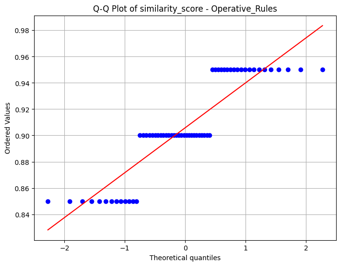

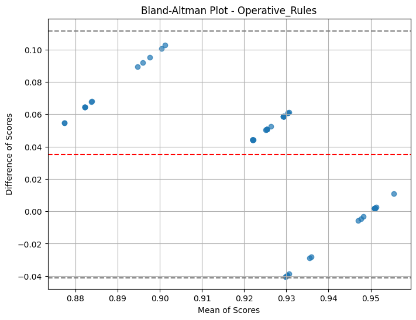

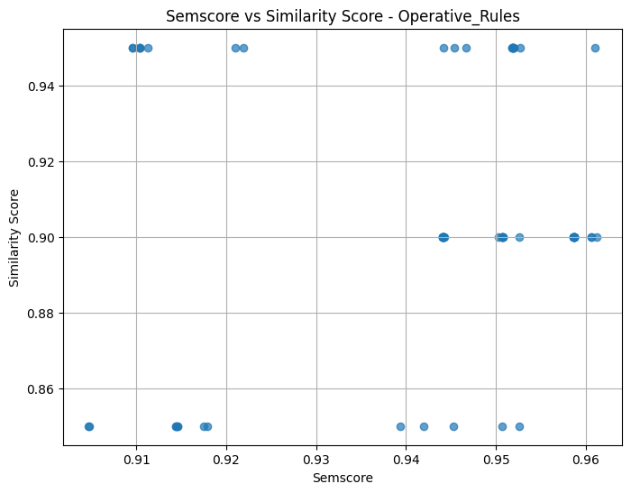

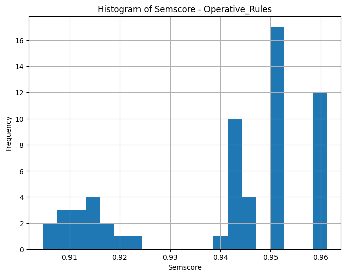

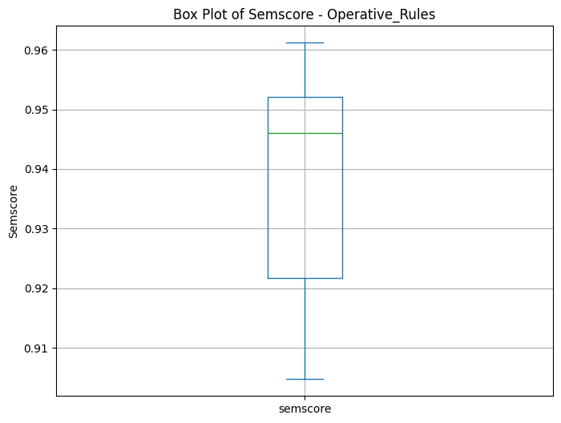

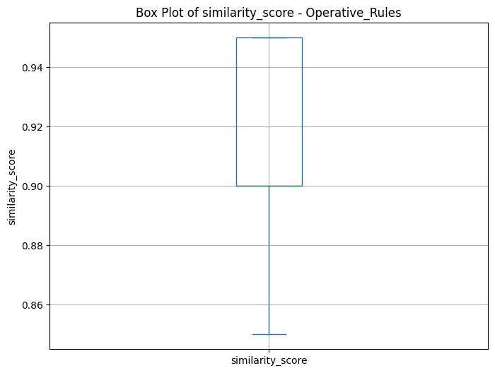

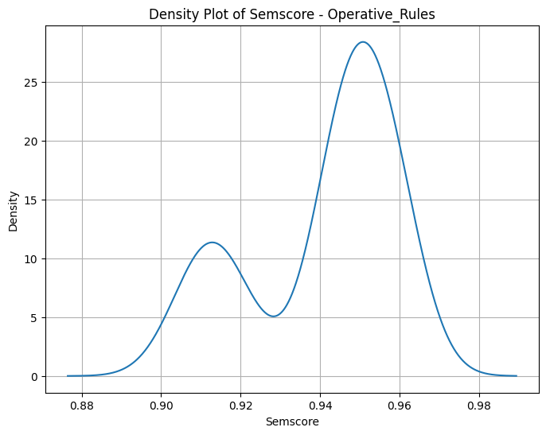

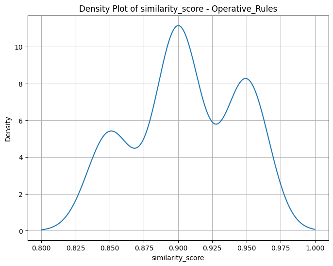

```
Count of Transformation Accuracy scores above 0.8: 33
```

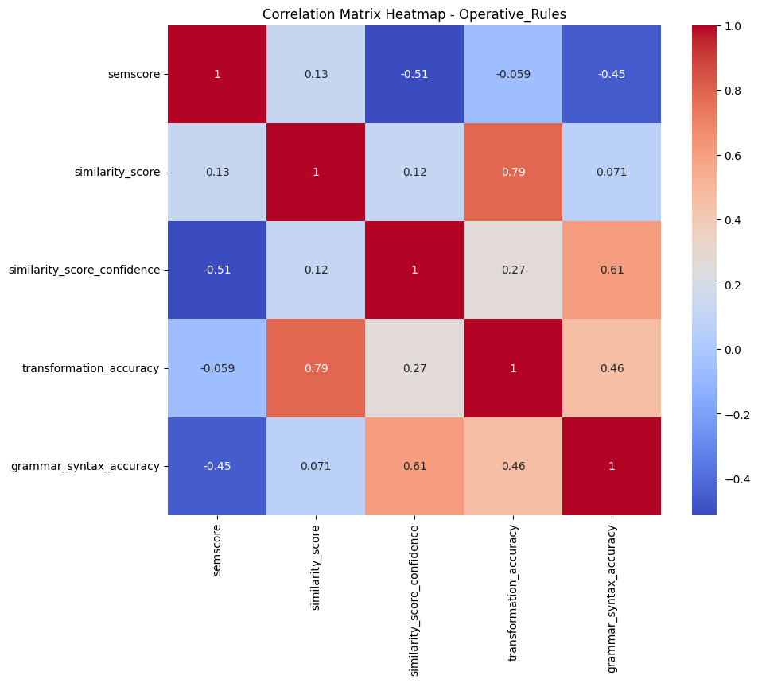

```
2024-12-09 23:24:47 - INFO -
Processing Element Type: Names
```

```
Semscore Statistics:
```

|  | semscore |
| --- | --- |
| count | 50.000000 |
| mean | 0.800785 |
| std | 0.057943 |
| min | 0.678210 |
| 25% | 0.785631 |
| 50% | 0.820770 |
| 75% | 0.850337 |
| max | 0.850504 |
| range | 0.172295 |
| IQR | 0.064706 |

```
Similarity Score Statistics:
```

|  | similarity_score |
| --- | --- |
| count | 50.000000 |
| mean | 0.940000 |
| std | 0.020203 |
| min | 0.900000 |
| 25% | 0.950000 |
| 50% | 0.950000 |
| 75% | 0.950000 |
| max | 0.950000 |
| range | 0.050000 |
| IQR | 0.000000 |

```
Pearson Correlation between semscore and similarity_score: 0.1313
Spearman Correlation between semscore and similarity_score: 0.3465
```

```
Intraclass Correlation Coefficient (ICC) between semscore and similarity_score: 0.1691
```

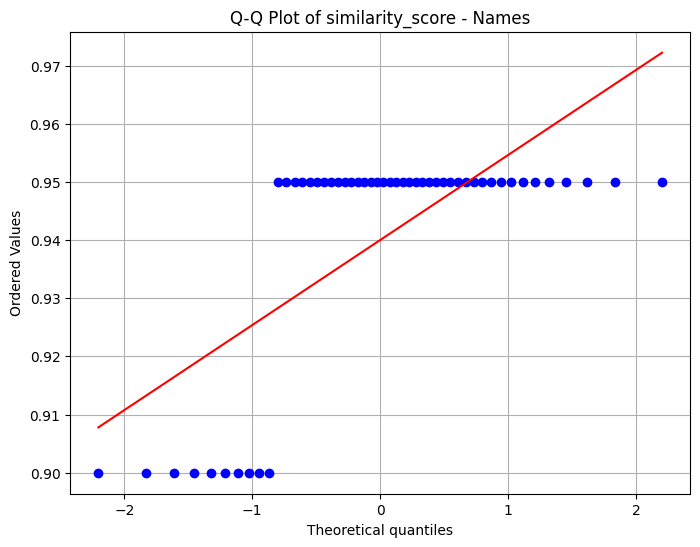

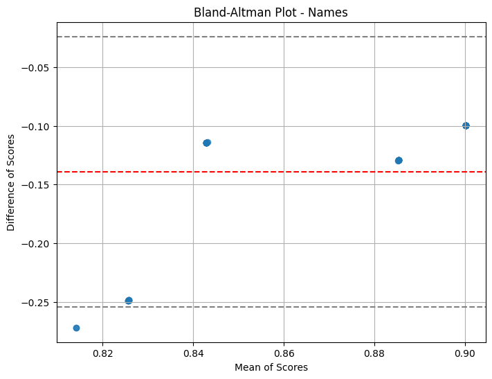

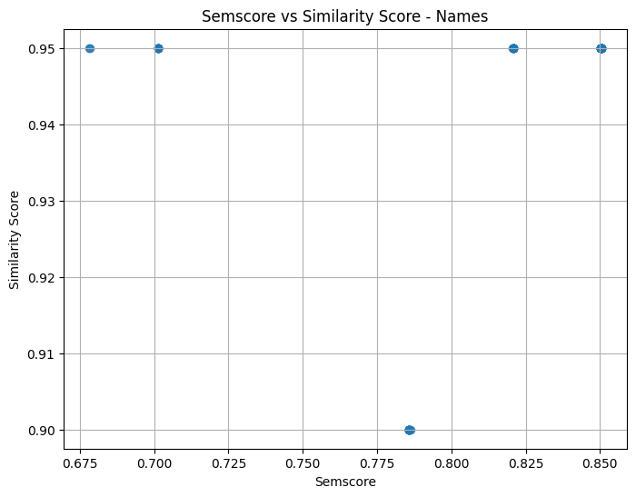

[33 more figures not shown]

```
Analysis saved to '../outputs/combined_analysis_results.xlsx'
```

```python
df = process_all_elements(elements_data, config["DEFAULT_OUTPUT_DIR"])
```

```python
df
```

|  | doc_id | statement_id | statement | sources | semscore | similarity_score | similarity_score_confidence | transformation_accuracy | grammar_syntax_accuracy | findings | element_type |
| --- | --- | --- | --- | --- | --- | --- | --- | --- | --- | --- | --- |
| 0 | § 275.0-2 | 3 | The Secretary of the Commission (Secretary) wi... | [(a)(2)] | 0.952598 | 0.90 | 0.85 | 0.8 | 0.95 | [The transformed sentence maintains the core m... | Operative_Rules |
| 1 | § 275.0-2 | 4 | If the Secretary certifies that the Commission... | [(a)(3)] | 0.944126 | 0.95 | 0.90 | 0.9 | 0.95 | [The transformed sentence maintains the origin... | Operative_Rules |
| 2 | § 275.0-5 | 1 | Notice of the initiation of the proceeding wil... | [(a)] | 0.946623 | 0.95 | 0.90 | 0.9 | 0.95 | [The transformed sentence maintains the origin... | Operative_Rules |
| 3 | § 275.0-5 | 2 | Any interested person may, within the period o... | [(a)] | 0.914574 | 0.85 | 0.90 | 0.8 | 0.95 | [The transformed sentence captures the essence... | Operative_Rules |
| 4 | § 275.0-5 | 3 | An order disposing of the matter will be issue... | [(b)] | 0.958645 | 0.90 | 0.85 | 0.8 | 0.90 | [The transformed sentence maintains the core m... | Operative_Rules |
| ... | ... | ... | ... | ... | ... | ... | ... | ... | ... | ... | ... |
| 545 | § 275.0-7 | 6 | A person is presumed to control a corporation ... | [(b)(1)(i)(A)] | 0.785793 | 0.90 | 0.85 | 0.8 | 0.95 | [The transformed sentence maintains the core m... | Fact_Types |
| 546 | § 275.0-7 | 7 | A person is presumed to control a partnership ... | [(b)(1)(ii)] | 0.938356 | 0.95 | 0.90 | 0.9 | 0.95 | [The transformed sentence maintains the origin... | Fact_Types |
| 547 | § 275.0-7 | 8 | A person is presumed to control a limited liab... | [(b)(1)(iii)] | 0.953968 | 0.95 | 0.90 | 0.9 | 0.95 | [The transformed sentence maintains the origin... | Fact_Types |
| 548 | § 275.0-7 | 9 | A person is presumed to control a trust if the... | [(b)(1)(iv)] | 0.917051 | 0.80 | 0.80 | 0.6 | 0.70 | [The transformed sentence incorrectly suggests... | Fact_Types |
| 549 | § 275.0-7 | 10 | Total assets means the total assets as shown o... | [(b)(2)] | 0.976969 | 0.95 | 0.90 | 0.9 | 0.95 | [The transformed sentence closely follows the ... | Fact_Types |

550 rows × 11 columns

### Prompt analysis

Analyze number of tokens from prompts and documents from last checkpoint using gpt-4o as a reference model.

According to [OpenAI | models](https://platform.openai.com/docs/models), the maximum number of tokens (context length) for gpt-4o is 128k.

The cost to use gpt-4o is 2.50 USD per 1m tokens in 2024-10-31. Source: [OpenAI | pricing](https://openai.com/pricing).

Extract elapse times and completions from all sessions.

```python
managers, file_info_list = get_all_checkpoints(config["DEFAULT_CHECKPOINT_DIR"])
```

```
2024-12-09 01:31:28 - INFO - DocumentManager restored from file: ../data/checkpoints/documents-2024-12-08-1.json
2024-12-09 01:31:28 - INFO - DocumentManager restored from file: ../data/checkpoints/documents-2024-12-08-10.json
2024-12-09 01:31:28 - INFO - DocumentManager restored from file: ../data/checkpoints/documents-2024-12-08-2.json
2024-12-09 01:31:28 - INFO - DocumentManager restored from file: ../data/checkpoints/documents-2024-12-08-3.json
2024-12-09 01:31:28 - INFO - DocumentManager restored from file: ../data/checkpoints/documents-2024-12-08-4.json
```

```
2024-12-09 01:31:28 - INFO - DocumentManager restored from file: ../data/checkpoints/documents-2024-12-08-5.json
2024-12-09 01:31:28 - INFO - DocumentManager restored from file: ../data/checkpoints/documents-2024-12-08-6.json
2024-12-09 01:31:28 - INFO - DocumentManager restored from file: ../data/checkpoints/documents-2024-12-08-7.json
2024-12-09 01:31:28 - INFO - DocumentManager restored from file: ../data/checkpoints/documents-2024-12-08-8.json
2024-12-09 01:31:28 - INFO - DocumentManager restored from file: ../data/checkpoints/documents-2024-12-08-9.json
```

```python
tokens_eval = {"doc_type": [], "elapsed_times": [], "completions": []}

for manager, file_info in zip(managers, file_info_list):
    # Process documents
    for key in manager.model_dump()["documents"].keys():
        if key[1].startswith("llm_"):
            doc = manager.retrieve_document(key[0], key[1])
            logger.info(f"Processing: {key[0]}, {key[1]}")
            elapsed_times = doc.elapsed_times
            logger.debug(f"Elapsed time: {elapsed_times}")
            completions = doc.completions
            logger.debug(f"Completions: {completions}")
            tokens_eval["doc_type"].append(key[1])
            tokens_eval["elapsed_times"].append(elapsed_times)
            tokens_eval["completions"].append(completions)
logger.info(f"Executions for evaluation: {len(tokens_eval['doc_type'])}")
```

[output not shown]

[output cut: 136 more lines]

```
2024-12-09 01:31:29 - INFO - Processing: § 275.0-7_P2, llm_response
2024-12-09 01:31:29 - INFO - Processing: classify_P1, llm_response_classification
2024-12-09 01:31:29 - INFO - Processing: classify_P2_Operative_rules, llm_response_classification
2024-12-09 01:31:29 - INFO - Processing: classify_P2_Definitional_terms, llm_response_classification
2024-12-09 01:31:29 - INFO - Processing: classify_P2_Definitional_names, llm_response_classification
2024-12-09 01:31:29 - INFO - Processing: classify_P2_Definitional_facts, llm_response_classification
2024-12-09 01:31:29 - INFO - Processing: transform_Operative_Rules, llm_response_transform
2024-12-09 01:31:29 - INFO - Processing: transform_Fact_Types, llm_response_transform
2024-12-09 01:31:29 - INFO - Processing: transform_Terms, llm_response_transform
2024-12-09 01:31:29 - INFO - Processing: transform_Names, llm_response_transform
2024-12-09 01:31:29 - INFO - Processing: validation_judge_Fact_Types, llm_validation
2024-12-09 01:31:29 - INFO - Processing: validation_judge_Terms, llm_validation
2024-12-09 01:31:29 - INFO - Processing: validation_judge_Names, llm_validation
2024-12-09 01:31:29 - INFO - Processing: validation_judge_Operative_Rules, llm_validation
2024-12-09 01:31:29 - INFO - Executions for evaluation: 190
```

Evaluate

```python
# Constants
reference_models = config["REFERENCE_MODELS"]["MAX_CONTEXT_LENGTH"]
price_per_million_tokens = config["REFERENCE_MODELS"]["PRICE_PER_MILLION_TOKENS"]

# Initialize an empty list to store the raw data
raw_data = []

# Assuming tokens_eval is already defined and contains the necessary data
for doc_type, elapsed_times, completions in zip(
    tokens_eval["doc_type"], tokens_eval["elapsed_times"], tokens_eval["completions"]
):
    for elapsed_time, completion in zip(elapsed_times, completions):
        raw_data.append(
            (
                file_info["filename"],
                doc_type,
                elapsed_time,
                completion["usage"],
                completion["created"],
                completion["model"],
            )
        )

prompt_analysis(raw_data, config["DEFAULT_OUTPUT_DIR"])
```

```
Overall Statistics:
 Total Tokens  Number of Samples  Average Elapsed Time (s)  Estimated Cost (USD)  Average Percentage of Context Length (%) Min Created Timestamp Max Created Timestamp                      origin              run_at
      5472538               1210                  3.819458             13.681345                                  3.533405   2024-11-30 00:08:20   2024-12-09 02:11:07 documents-2024-12-08-9.json 2024-12-09 01:31:29

Statistics by Sample Type (doc_type):
                   doc_type  total_tokens  num_samples  average_elapsed_time  average_tokens  estimated_cost  average_percentage_context_length                    filename              run_at
               llm_response        272850           60             28.951583     4547.500000        0.682125                           3.552734 documents-2024-12-08-9.json 2024-12-09 01:31:29
llm_response_classification        370390           50              8.280727     7407.800000        0.925975                           5.787344 documents-2024-12-08-9.json 2024-12-09 01:31:29
     llm_response_transform       2480495          550              2.315991     4509.990909        6.201237                           3.523430 documents-2024-12-08-9.json 2024-12-09 01:31:29
             llm_validation       2348803          550              2.175670     4270.550909        5.872008                           3.336368 documents-2024-12-08-9.json 2024-12-09 01:31:29

Statistics by Model:
            model  total_tokens  num_samples  average_elapsed_time  average_tokens  average_percentage_context_length                    filename              run_at  estimated_cost      cost
gpt-4o-2024-08-06       5472538         1210              3.819458     4522.758678                           3.533405 documents-2024-12-08-9.json 2024-12-09 01:31:29       13.681345 13.681345

Additional Statistics:
 Average Completion Tokens  Average Prompt Tokens  Average Total Tokens per Sample  Total Elapsed Time (s)  Average Tokens per Second                      origin              run_at
                314.103306            4208.655372                      4522.758678             4621.544686                1959.897985 documents-2024-12-08-9.json 2024-12-09 01:31:29
```